# NILC Analysis V1

Viola Glenn, viola.glenn@gmail.com

March 23, 2017

Goal: Create some preliminary viz to address potential for disproportionate impact based on religion. Uses country list from 2nd Executive Order. Also utilizes data compiled by Amanda Alvarez at https://data.world/gecky/20020101-20170321-rpc-refugees.

# Step 1: Call Libraries

```r
library(plyr)
library(dplyr)
library(ggplot2)
library(readr)
library(tidyr)
library(scales)
```

# Step 2: Load Data

I don’t have access to data.world at my machine because of file sharing restrictions. Instead I’ve downloaded the data and will pull it from my files. Also dropping many blank (all NA) rows that are imported with the file.

```r
RPC <- read_delim("C:/Users/vglenn/Documents/Misc/D4D/Immigration Connect/RPC Vivek/Data/RPC_data.csv",
                       "\t", escape_double = FALSE, trim_ws = TRUE)
```

```r
head(RPC)
```

```
## # A tibble: 6 x 4
##   Nationality CalendarYear Religion NumRefugees
##         <chr>        <int>    <chr>       <dbl>
## 1 Afghanistan         2002  Atheist           0
## 2 Afghanistan         2003  Atheist           0
## 3 Afghanistan         2004  Atheist           0
## 4 Afghanistan         2005  Atheist           0
## 5 Afghanistan         2006  Atheist           6
## 6 Afghanistan         2007  Atheist           0
```

```r
RPC<-na.omit(RPC)
```

# Step 3: Analysis Set-Up

I pass R countries impacted by ban and group religions:

```r
banned <-c ('Iran','Libya','Somalia','Sudan','Syria','Yemen')

#Add banned flag to master dataset
RPC$banned <- ifelse(RPC$Nationality %in% banned, "Banned", "Not Banned")

#Create crosswalk
all_relig <- c('Christian', 'Moslem', 'Unknown', 'Catholic', 'No Religion', 'Protestant',
               'Pentecostalist', 'Moslem Suni', 'Evangelical Christian', 'Baptist',
               'Other Religion', 'Seventh Day Adventist', 'Jehovah Witness', 'Orthodox',
               'Atheist', 'Jewish', 'Buddhist', 'Methodist', 'Bahai', 'Lutheran',
               'Moslem Shiite', 'Hindu', 'Ancestral Worship', 'Animist',
               'Russian Orthodox', 'Coptic', 'Greek Orthodox', 'Mennonite', 'Chaldean',
               'Moslem Ismaici', 'Ukr Orthodox', 'Zoroastrian', 'Cao Dai',
               'Hare Krishna',"Kaaka'i", 'Kirat', 'Old Believer', 'Sabeans-Mandean',
               'Uniate', 'Yazidi', 'Ahmadiyya', 'Drew', 'Hoa Hao',
               'Ukrainian Autocephalous Orthodox',
               'Ukrainian Orthodox Kyivan Patriarchate')

big_categories <- c('Christian', 'Moslem', 'Unknown', 'Christian', 'No Religion',
                    'Christian', 'Christian', 'Moslem', 'Christian', 'Christian',
                    'Other', 'Christian', 'Christian', 'Christian', 'No Religion',
                    'Jewish', 'Other', 'Christian', 'Other', 'Christian', 'Moslem',
                    'Other', 'Other', 'Other', 'Christian', 'Christian', 'Christian',
                    'Christian', 'Christian', 'Moslem', 'Christian', 'Other', 'Other',
                    'Other', 'Other', 'Other', 'Other', 'Other', 'Christian',
                    'Other', 'Moslem', 'Other', 'Other', 'Christian', 'Christian')

lookup <- data.frame(all_relig, big_categories)

print(lookup)
```

```
##                                 all_relig big_categories
## 1                               Christian      Christian
## 2                                  Moslem         Moslem
## 3                                 Unknown        Unknown
## 4                                Catholic      Christian
## 5                             No Religion    No Religion
## 6                              Protestant      Christian
## 7                          Pentecostalist      Christian
## 8                             Moslem Suni         Moslem
## 9                   Evangelical Christian      Christian
## 10                                Baptist      Christian
## 11                         Other Religion          Other
## 12                  Seventh Day Adventist      Christian
## 13                        Jehovah Witness      Christian
## 14                               Orthodox      Christian
```

[output cut: 31 more lines]

```r
#Add religion categories to master dataset
RPC <- left_join(RPC, lookup, by=c('Religion'='all_relig'))

#Here's the distribution we're looking at:
table(RPC$big_categories)
```

```
##
##   Christian      Jewish      Moslem No Religion       Other     Unknown
##        7456         384        2144        1168        1744         992
```

# Step 4: Some quick analysis

Summarise percentage of refugees that would have been historically impacted, by religion.

```r
#Sum by whether country is banned, year, and religion
summary <- RPC %>%
  group_by(banned, CalendarYear, big_categories) %>%
  summarise(refugees = sum(NumRefugees))

#Reformat for easier work
summary <- spread(summary, banned, refugees)

#Create percentage banned variable
summary$percentage_banned <- summary$Banned/(summary$`Not Banned`+summary$Banned)

#A glimpse of where we stand now
head(summary)
```

```
## Source: local data frame [6 x 5]
## Groups: CalendarYear [1]
##
##   CalendarYear big_categories Banned Not Banned percentage_banned
##          <int>         <fctr>  <dbl>      <dbl>             <dbl>
## 1         2002      Christian   1327      13999       0.086584888
## 2         2002         Jewish    373       2061       0.153245686
## 3         2002         Moslem    600       6291       0.087070091
## 4         2002    No Religion      7       1442       0.004830918
## 5         2002          Other    269        152       0.638954869
## 6         2002        Unknown      5       3198       0.001561037
```

# Step 5: Viz

Create final viz to highlight refugee nationalities overtime as they relate to the EO.

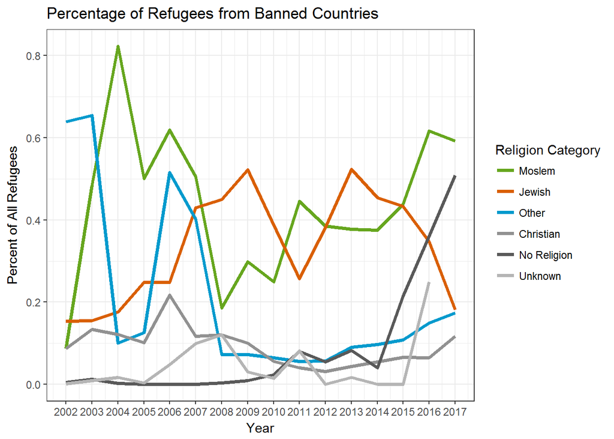

```r
#Order my levels as I'd like them displayed
levels <- c('Moslem', 'Jewish', 'Other', 'Christian', 'No Religion', 'Unknown')
summary$big_categories <- as.character(summary$big_categories)
summary$big_categories <- factor(summary$big_categories, levels = levels)

#Assign colors to levels to highlight areas of bigger impact
colors <- c("#66A61E", '#D95F02', 'deepskyblue3', 'gray57','gray35' , 'gray71')
names(colors) <- levels(as.factor(summary$big_categories))

#Plot
ggplot(data = summary, aes(x = CalendarYear, y = percentage_banned,
                           color = as.factor(big_categories))) +
  geom_line(size = 1.25) +
  scale_color_manual(name = "Religion Category", values=colors) +
  scale_x_continuous(breaks = 2002:2017) +
  scale_y_continuous(labels = comma) +
  labs(x = "Year", y = "Percent of All Refugees",
       title = "Percentage of Refugees from Banned Countries") +
  theme(axis.text = element_text(size = 12),
        axis.title = element_text(size = 14,face = "bold")) +
  theme_bw()
```